# VisitorCounts

In this vignette, functions in the VisitorCounts package are demonstrated using park visitation data from Yellowstone National Park.

# Sample Datasets: `park_visitation` and `flickr_userdays`

```r
library(VisitorCounts)
data("park_visitation")
data("flickr_userdays")
```

## Sample data for Yellowstone National Park

```r
yellowstone_pud <- park_visitation[park_visitation$park == "YELL",]$pud #photo user days
yellowstone_nps <- park_visitation[park_visitation$park == "YELL",]$nps #national park service counts

yellowstone_pud <- ts(yellowstone_pud, start = 2005, freq = 12)
yellowstone_nps <- ts(yellowstone_nps, start = 2005, freq = 12)

log_yellowstone_pud <- log(yellowstone_pud)
log_yellowstone_nps <- log(yellowstone_nps)

log_flickr_userdays <- log(flickr_userdays)
```

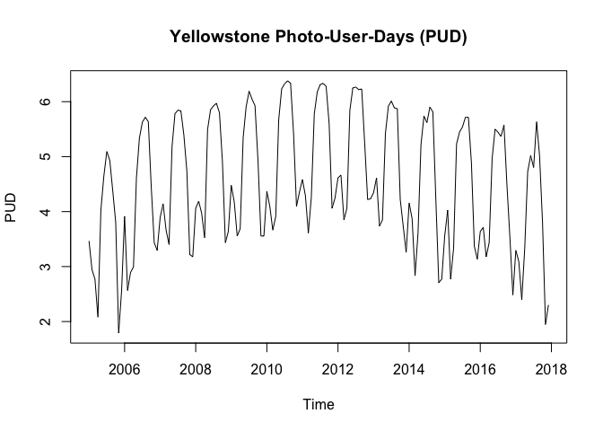

```r
plot(log_yellowstone_pud, main = "Yellowstone Photo-User-Days (PUD)", ylab = "PUD")
```

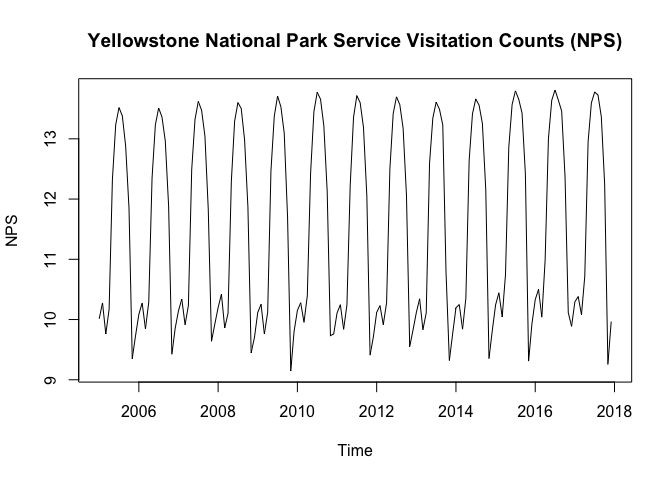

```r
plot(log_yellowstone_nps, main = "Yellowstone National Park Service Visitation Counts (NPS)", ylab = "NPS")
```

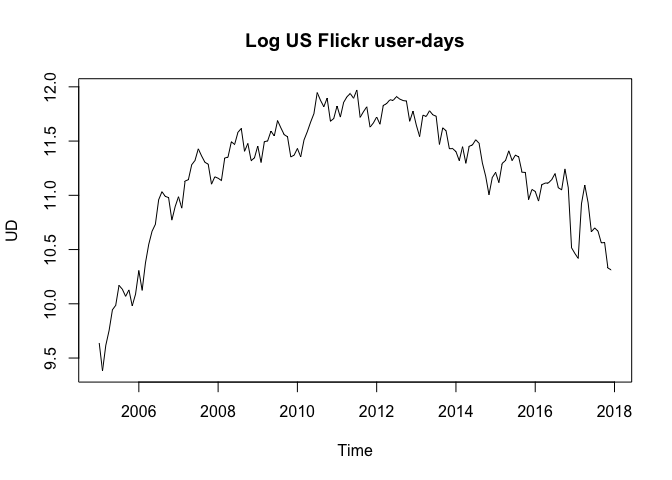

```r
plot(log_flickr_userdays, main = "Log US Flickr user-days", ylab = "UD")
```

# visitation_model()

The `visitation_model()` function uses social media data, such as the log flickr photo-user-days in `log_yellowstone_pud`, coupled with a popularity measure of the social media platform, like the log US flickr userdays in `log_flickr_userdays`, to model percent changes in visitation counts. By default, `visitation_model()` assumes that no visitation counts are available.

```r
yell_visitation_model <- visitation_model(log_yellowstone_pud,
                                          log_flickr_userdays, is_output_logged = TRUE, is_input_logged = TRUE)
```

```
## The additive constant for the model is assumed to be equal to zero.
##             If a better constant is known, change the value in the constant argument.
##             Instead, the actual series may be supplied in the ref_series argument.
```

```
## When no or linear trend is assumed, popularity_proxy will not be used.
```

If national park data is available, a reference series may be supplied to assist in parameter estimates:

```r
yell_visitation_model_nps <- visitation_model(log_yellowstone_pud,
                                              log_flickr_userdays,
                                              ref_series = log_yellowstone_nps, is_output_logged = TRUE, is_input_logged = TRUE)
```

```
## When no or linear trend is assumed, popularity_proxy will not be used.
```

## plot.visitation_model()

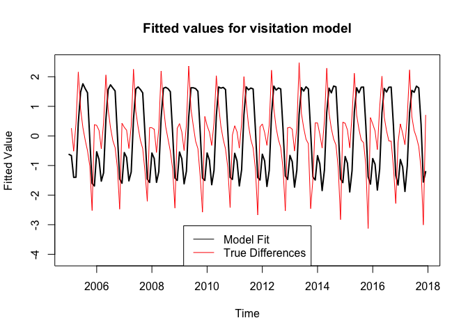

```r
true_differences <- diff(log_yellowstone_nps)
lower_bound <- min(c(true_differences,diff(yell_visitation_model$visitation_fit)))-1
upper_bound <- max(c(true_differences,diff(yell_visitation_model$visitation_fit)))

plot(yell_visitation_model, ylim = c(lower_bound, upper_bound), lwd = 2)
lines(diff(log_yellowstone_nps), col = "red")
legend("bottom",c("Model Fit","True Differences"),col = c("black","red"),lty = c(1,1))
```

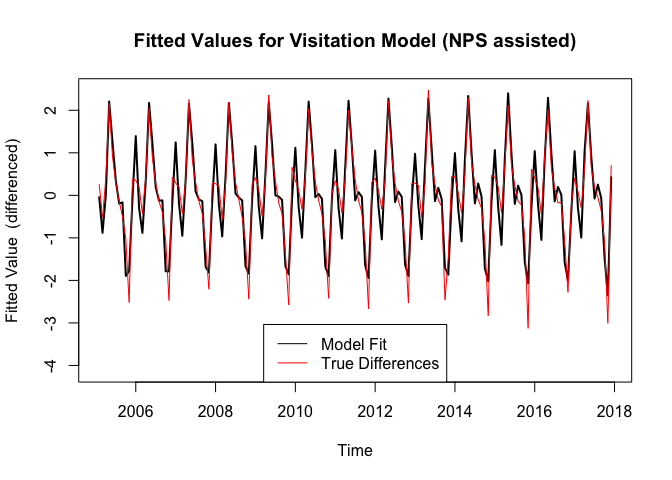

```r
true_differences <- diff(log_yellowstone_nps)
lower_bound <- min(c(true_differences,diff(yell_visitation_model_nps$visitation_fit)))-1
upper_bound <- max(c(true_differences,diff(yell_visitation_model_nps$visitation_fit)))

plot(yell_visitation_model_nps, ylim = c(lower_bound, upper_bound),
     lwd = 2,
     main = "Fitted Values for Visitation Model (NPS assisted)", difference = TRUE)
lines(true_differences, col = "red")
legend("bottom",c("Model Fit","True Differences"),col = c("black","red"),lty = c(1,1))
```

## summary.visitation_model()

Parameters can be inspected using `summary.visitation_model()`. Two examples can be seen below:

```r
summary(yell_visitation_model)
```

```
## Call: visitation_model(onsite_usage = log_yellowstone_pud, popularity_proxy = log_flickr_userdays,
##     is_input_logged = TRUE, is_output_logged = TRUE)
##
##  Parameter Estimates:
## ===============================
## Parameter:           Estimate:
## ----------           ---------
## Beta_0 (Constant):   0
## Beta_1 (Seasonality): 1.308
## Beta_2 (Trend):      0
## Lag:                 0
## Lag Criterion:       cross-correlation
## ===============================
```

```r
summary(yell_visitation_model_nps)
```

```
## Call: visitation_model(onsite_usage = log_yellowstone_pud, popularity_proxy = log_flickr_userdays,
##     ref_series = log_yellowstone_nps, is_input_logged = TRUE,
##     is_output_logged = TRUE)
##
##  Parameter Estimates:
## ===============================
## Parameter:           Estimate:
## ----------           ---------
## Beta_0 (Constant):   11.371
## Beta_1 (Seasonality): 1.572
## Beta_2 (Trend):      0.002
## Lag:                 0
## Lag Criterion:       cross-correlation
## ===============================
```

## predict.visitation_model()

Forecasts can be made using `predict.visitation_model()`, whose output is a `visitation_forecast` class object which can be inspected using `plot` or `summary` functions.

```r
yellowstone_visitation_forecasts <- predict(yell_visitation_model, n_ahead = 12)
```

```
## WARNING : the model's constant (Beta_0) parameter is 0. This will result in likely inaccurate predictions.
```

```
## The model constant is understood as the mean log adjusted monthly visitation relative to the base month.
```

```
## Please provide a ref_series to the visitation_model object or provide your own custom value for the constant to visitation_model constructor
```

```r
yellowstone_visitation_forecasts_nps <- predict(yell_visitation_model_nps, n_ahead = 12)

yellowstone_visitation_forecasts_withpast <- predict(yell_visitation_model, n_ahead = 12, only_new = FALSE)
```

```
## WARNING : the model's constant (Beta_0) parameter is 0. This will result in likely inaccurate predictions.
```

```
## The model constant is understood as the mean log adjusted monthly visitation relative to the base month.
```

```
## Please provide a ref_series to the visitation_model object or provide your own custom value for the constant to visitation_model constructor
```

### plot.visitation_forecast()

Forecasts can be plotted using `plot.visitation_forecast()`:

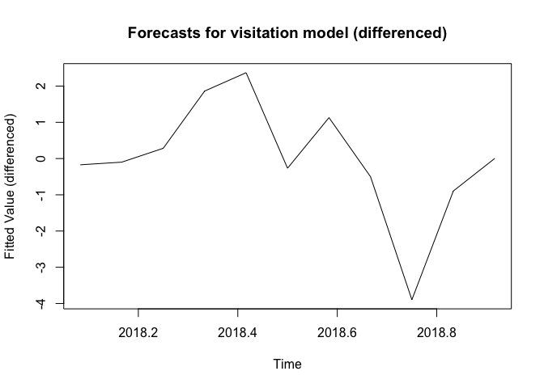

```r
plot(yellowstone_visitation_forecasts, difference = TRUE)
```

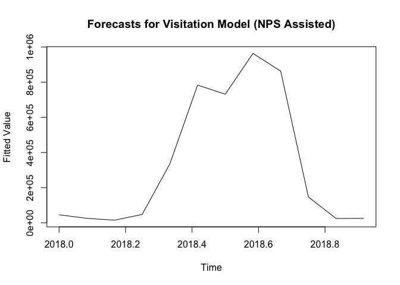

```r
plot(yellowstone_visitation_forecasts_nps, main = "Forecasts for Visitation Model (NPS Assisted)", date_label = "%b", date_breaks = "1 month")
```

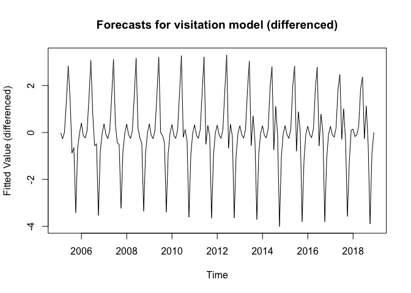

```r
plot(yellowstone_visitation_forecasts_withpast, difference = TRUE, date_breaks = "1 year", date_label = "%y")
```

### summary.visitation_forecast()

```r
summary(yellowstone_visitation_forecasts)
```

```
## Visitation model forecasts:
##
## Parameter Estimates:
## ===============================
## Parameter:           Estimate:
## ----------           ---------
## Beta_0 (Constant):   0
## Beta_1 (Seasonality): 1.308
## Beta_2 (Trend):      0
## Lag:
## ===============================
## Criterion for Lag Estimate: cross-correlation
## Number of Forecasts: 12
```

```r
summary(yellowstone_visitation_forecasts_nps)
```

```
## Visitation model forecasts:
##
## Parameter Estimates:
## ===============================
## Parameter:           Estimate:
## ----------           ---------
## Beta_0 (Constant):   11.371
## Beta_1 (Seasonality): 1.572
## Beta_2 (Trend):      0.002
## Lag:
## ===============================
## Criterion for Lag Estimate: cross-correlation
## Number of Forecasts: 12
```

# auto_decompose()

The automatic decomposition function uses singular-spectrum analysis, as implemented by the Rssa package, in conjunction with an automated procedure for classifying components to decompose a time series into trend, seasonality and noise.

```r
yell_pud_decomposition <- auto_decompose(yellowstone_pud)
```

## plot.decomposition()

Several plot options are available for examining this decomposition.

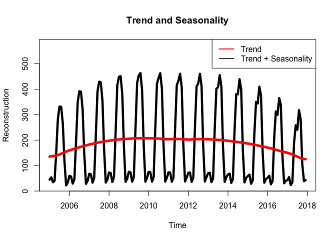

```r
plot(yell_pud_decomposition)
```

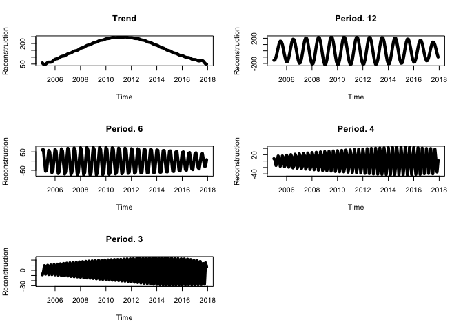

```r
plot(yell_pud_decomposition, type = "period")
```

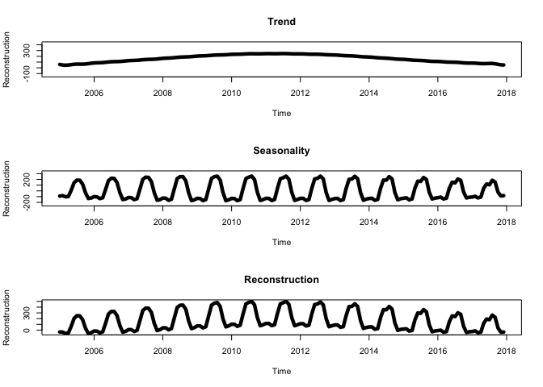

```r
plot(yell_pud_decomposition, type = "classical")
```

## summary.decomposition()

The eigenvector grouping can be examined using `summary.decomposition`.

```r
summary(yell_pud_decomposition)
```

```
## Decomposition:
##
## Period or Component  || Eigenvector Grouping
## ===================  || ====================
##  12                  || 2, 3
##  6                   || 5, 6
##  4                   || 9, 10
##  3                   || 12, 13
##  Trend               || 1, 4
##
##  Window Length: 72
##  Number of Observations: 156
```

## predict.decomposition()

Forecasts can be made using `predict.decomposition()`:

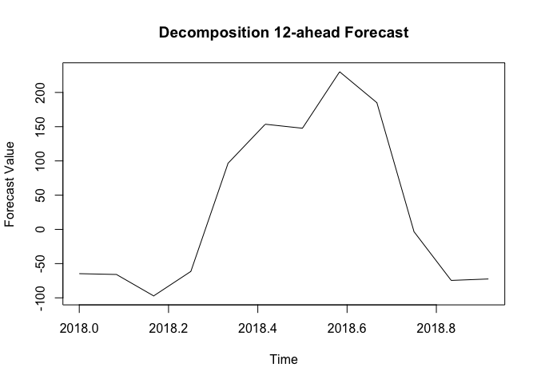

```r
plot(predict(yell_pud_decomposition, n_ahead = 12)$forecast, main = "Decomposition 12-ahead Forecast", ylab = "Forecast Value")
```